# 建模初探

戎翔

2020/4/2

一、 本次疫情来势汹汹，大有席卷全球之势。而意大利作为古罗马的遗存，不论是其政治，经济角色亦或文化影响力都称得上欧洲比较重要国家。而且意大利一年前正式加入了新丝绸之路（一带一路）项目，两国签署了包括谅解备忘录的多达29项协议，这在G7成员国当中是第一家。我们使用的是意大利 2020 年 3 月 1 日到 2020 年 3 月 30 日的疫情数据。数据来自世界卫生组织和意大利卫生部。 二、 我们准备用时间序列的Arima模型拟合累计死亡序列，以评估疫情的发展情况。ARIMA是一种比较常用的基于历史数据来做预测的时间序列模型。时间序列在商业中有很多应用，比如它可以解释销售中的季节性规律；可以预测新客或流失客户的数量等。ARIMA的全称是auto-regressive integrated moving average，主要是由三个参数确定的，即(p,d,q)。p指的是回归过程中某个时间点的取值依赖于过去的p个时间点的取值，d为差分次数，q为模型的的误差是之前误差的组合。 从图片可以看出原始序列是显著非平稳序列，累计死亡人数曲线呈现指数增加的趋势，因此尝试用二阶差分让其平稳。从图中可以看到在3月15号之前累计死亡人数增加较慢，15号以后逐渐递增。

## 累计死亡

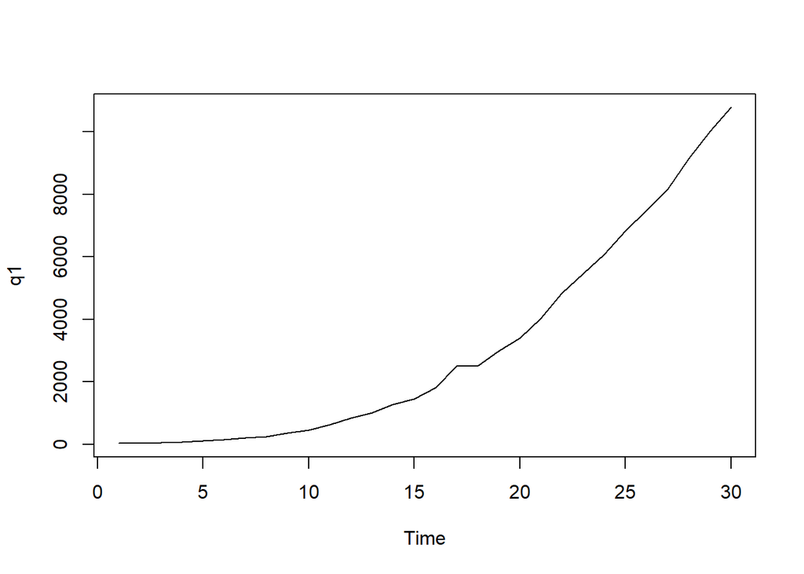

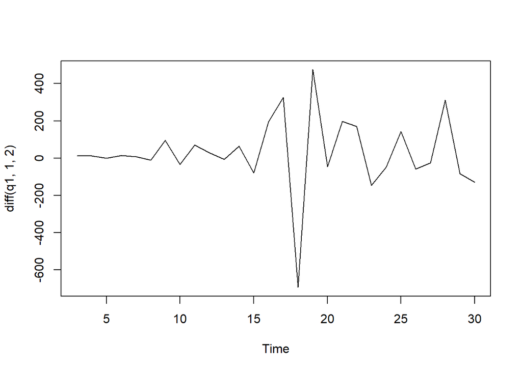

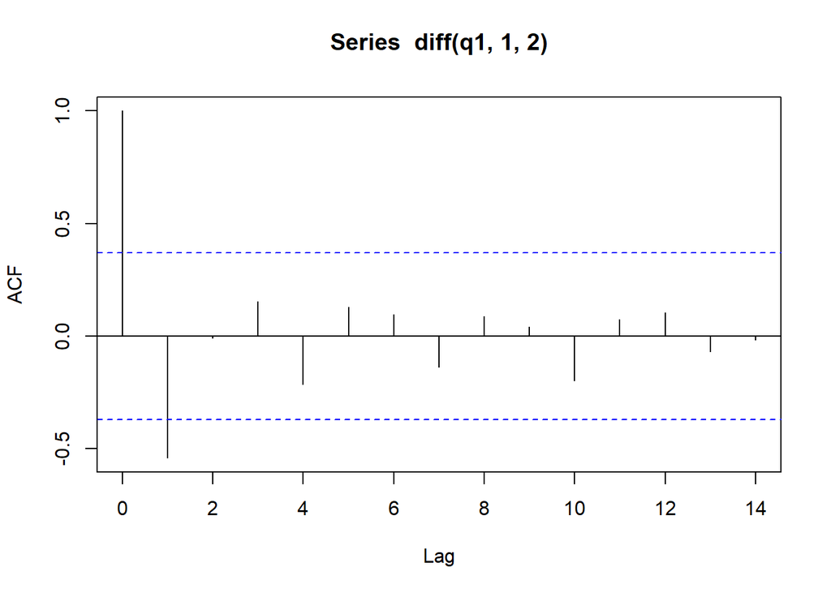

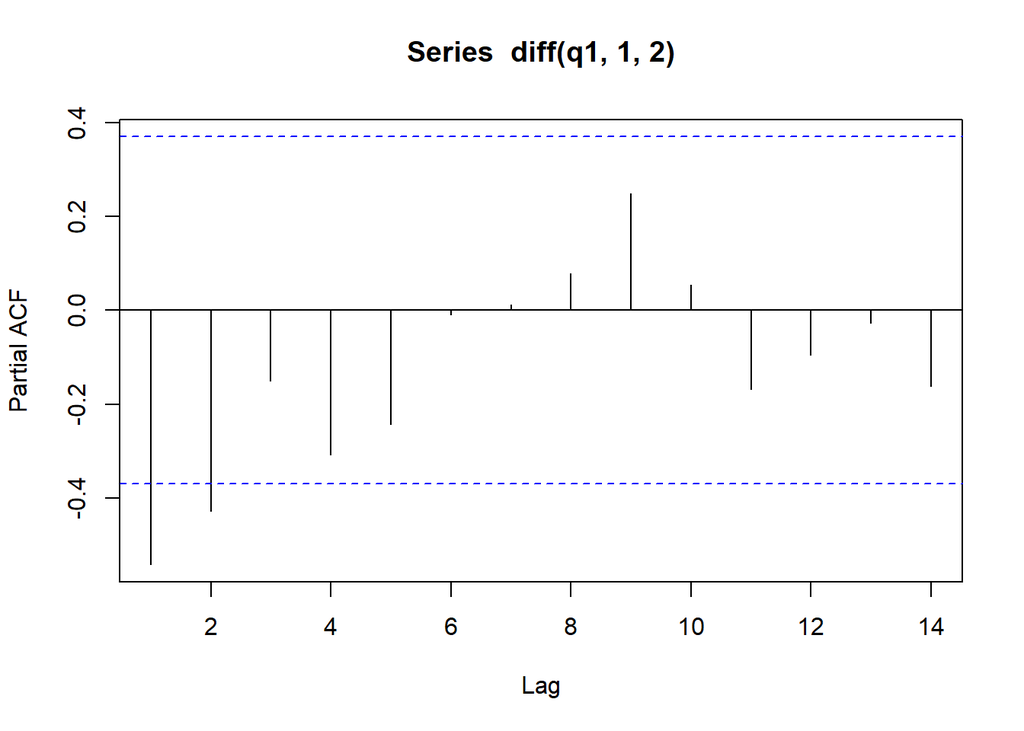